# Loading and preprocessing the data

## Loading and preprocessing the data

```r
data <- read.csv('activity.csv')
```

## What is mean total number of steps taken per day?

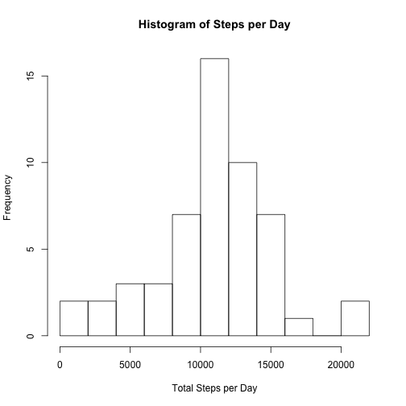

```r
total_steps_per_day <- aggregate(data$steps, by=list(data$date), FUN=sum)
hist(total_steps_per_day$x, breaks=10, main="Histogram of Steps per Day", xlab="Total Steps per Day")
```

```r
mean_steps_per_day <- aggregate(steps ~ date, data, mean, na.action=na.omit)
median_steps_per_day <- aggregate(steps ~ date, data, median, na.action=na.omit)

mean_steps_per_day
```

```
##          date   steps
## 1  2012-10-02  0.4375
## 2  2012-10-03 39.4167
## 3  2012-10-04 42.0694
## 4  2012-10-05 46.1597
## 5  2012-10-06 53.5417
## 6  2012-10-07 38.2465
## 7  2012-10-09 44.4826
## 8  2012-10-10 34.3750
## 9  2012-10-11 35.7778
## 10 2012-10-12 60.3542
## 11 2012-10-13 43.1458
## 12 2012-10-14 52.4236
## 13 2012-10-15 35.2049
## 14 2012-10-16 52.3750
```

[output cut: 39 more lines]

```r
median_steps_per_day
```

```
##          date steps
## 1  2012-10-02     0
## 2  2012-10-03     0
## 3  2012-10-04     0
## 4  2012-10-05     0
## 5  2012-10-06     0
## 6  2012-10-07     0
## 7  2012-10-09     0
## 8  2012-10-10     0
## 9  2012-10-11     0
## 10 2012-10-12     0
## 11 2012-10-13     0
## 12 2012-10-14     0
## 13 2012-10-15     0
## 14 2012-10-16     0
```

[output cut: 39 more lines]

## What is the average daily activity pattern?

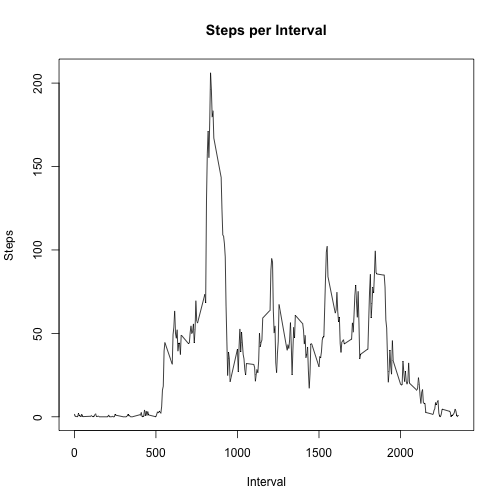

```r
mean_steps_per_interval <- aggregate(steps ~ interval, data, mean, na.action=na.omit)
plot(mean_steps_per_interval, type='l', xlab="Interval", ylab="Steps", main="Steps per Interval")
```

The 5 minute interval with the maximum number of steps is obtained with:

```r
max_interval = mean_steps_per_interval$interval[which.max(mean_steps_per_interval$steps)]

max_interval
```

```
## [1] 835
```

## Imputing missing values

Calculate and report the total number of missing values in the dataset (i.e. the total number of rows with NAs)

```r
number_of_nas <- sum(is.na(data$steps))
number_of_nas
```

```
## [1] 2304
```

Devise a strategy for filling in all of the missing values in the dataset. The strategy does not need to be sophisticated.

NAs will be filled in by the mean of the 5-minute interval rounded to the nearest integer.

First we create a copy of the dataset.

```r
imputed_data = data
```

Next, we pull out the indices where the interval in the dataset match the interval in the mean step per interval data, and also match the NA values in the dataset.

```r
step_indices <- mean_steps_per_interval$interval == imputed_data$interval[is.na(data$steps)]
```

Finally, we replace the NA values with the mean steps per interval values.

```r
imputed_data$steps[is.na(imputed_data$steps)] = round(mean_steps_per_interval$steps[step_indices])
```

Now, we can create a new histogram based on the imputed data.

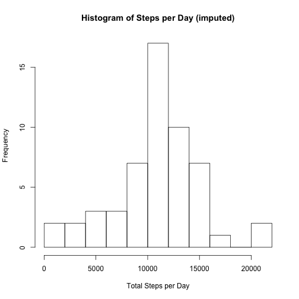

```r
imputed_total_steps_per_day <- aggregate(steps ~ date, imputed_data, sum)
hist(imputed_total_steps_per_day$steps, breaks=10, main="Histogram of Steps per Day (imputed)", xlab="Total Steps per Day")
```

We do the same for a new mean / median

```r
imputed_mean_steps_per_day <- aggregate(steps ~ date, imputed_data, mean, na.action=na.omit)
imputed_median_steps_per_day <- aggregate(steps ~ date, imputed_data, median, na.action=na.omit)

imputed_mean_steps_per_day
```

```
##          date   steps
## 1  2012-10-01 37.3681
## 2  2012-10-02  0.4375
## 3  2012-10-03 39.4167
## 4  2012-10-04 42.0694
## 5  2012-10-05 46.1597
## 6  2012-10-06 53.5417
## 7  2012-10-07 38.2465
## 8  2012-10-09 44.4826
## 9  2012-10-10 34.3750
## 10 2012-10-11 35.7778
## 11 2012-10-12 60.3542
## 12 2012-10-13 43.1458
## 13 2012-10-14 52.4236
## 14 2012-10-15 35.2049
```

[output cut: 40 more lines]

```r
imputed_median_steps_per_day
```

```
##          date steps
## 1  2012-10-01  34.5
## 2  2012-10-02   0.0
## 3  2012-10-03   0.0
## 4  2012-10-04   0.0
## 5  2012-10-05   0.0
## 6  2012-10-06   0.0
## 7  2012-10-07   0.0
## 8  2012-10-09   0.0
## 9  2012-10-10   0.0
## 10 2012-10-11   0.0
## 11 2012-10-12   0.0
## 12 2012-10-13   0.0
## 13 2012-10-14   0.0
## 14 2012-10-15   0.0
```

[output cut: 40 more lines]

Comparing the two histograms, we can see no material effect from imputing data.

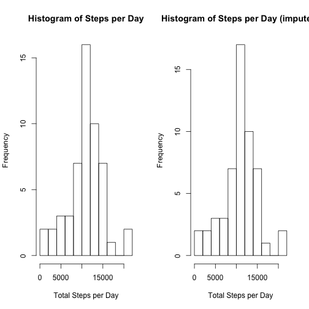

```r
par(mfrow=c(1,2))
hist(total_steps_per_day$x, breaks=10, main="Histogram of Steps per Day", xlab="Total Steps per Day")
hist(imputed_total_steps_per_day$steps, breaks=10, main="Histogram of Steps per Day (imputed)", xlab="Total Steps per Day")
```

## Are there differences in activity patterns between weekdays and weekends?

To further explore the impact of weekday vs weekend activity, we can factor the data.

```r
imputed_data$day[weekdays(as.POSIXct(imputed_data$date)) %in% c("Monday", "Tuesday", "Wednesday", "Thursday", "Friday")] = "Weekday"
imputed_data$day[weekdays(as.POSIXct(imputed_data$date)) %in% c("Saturday", "Sunday")] = "Weekend"

factored_data = as.factor(imputed_data$day)
```

Finally, we plot the data based on weekday vs weekend.

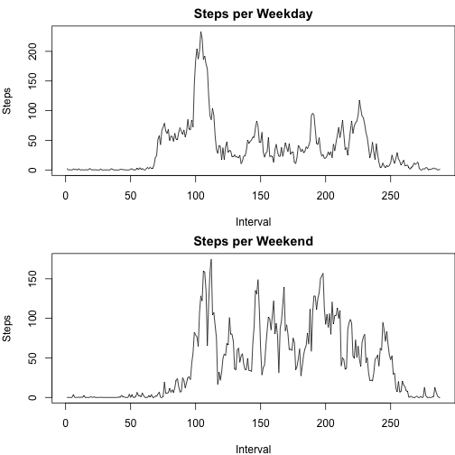

```r
mean_steps_per_daytype <- aggregate(steps ~ interval + day, imputed_data, mean, na.action=na.omit)

par(mfrow=c(2,1))
par(mar=c(4,4,2,0))
plot(mean_steps_per_daytype$steps[mean_steps_per_daytype$day == "Weekday"], type='l', xlab="Interval", ylab="Steps", main="Steps per Weekday")
plot(mean_steps_per_daytype$steps[mean_steps_per_daytype$day == "Weekend"], type='l', xlab="Interval", ylab="Steps", main="Steps per Weekend")
```